# New_Final_independant_Assignment

kithsiri Jayakody

12/17/2020

## R Markdown

Section 1: Research question

This dataset has given 44 columns with 23 categorical variables and 21 numeric variables.

1. Does the questionnaire measure a single construct Or is it possible that there are multiple aspects which is used to measure the overall average score of the professional evaluation G_SC. ( this PCA is doing to reduce the dymensions to predict the G_SC.)

In order to pre process the dataset following aspects are done as below.

Section 2:

```r
# loading the required files

needed_packages <- c("psych",  "REdaS", "Hmisc", "corrplot", "ggcorrplot", "factoextra",  "nFactors","readxl","dplyr", "dummy","data.table","mltools","caret")
# Extract not installed packages
not_installed <- needed_packages[!(needed_packages %in% installed.packages()[ , "Package"])]
# Install not installed packages
if(length(not_installed)) install.packages(not_installed, repos = "http://cran.us.r-project.org")
library(psych)
library(REdaS)
library(Hmisc)
library(corrplot)
library(ggcorrplot)
library(factoextra)#Used for principal component analysis to get a different view of eigenvalues
library(nFactors)
library(readxl)
library(dplyr)
library(dummy)
library(data.table)
library(mltools)
```

loading the datafile for analytics

```r
#load the dataset and remove every row when students didn't answer a question

setwd('D:/statistics')
# dataset is loading
df <- read_excel("data_academic_performance.xlsx")
```

```
## * `` -> ...10
```

```r
str(df)
```

```
## tibble [12,411 x 45] (S3: tbl_df/tbl/data.frame)
##  $ COD_S11         : chr [1:12411] "SB11201210000129" "SB11201210000137" "SB11201210005154" "SB11201210007504" ...
##  $ GENDER          : chr [1:12411] "F" "F" "M" "F" ...
##  $ EDU_FATHER      : chr [1:12411] "Incomplete Professional Education" "Complete Secundary" "Not sure" "Not sure" ...
##  $ EDU_MOTHER      : chr [1:12411] "Complete technique or technology" "Complete professional education" "Not sure" "Not sure" ...
##  $ OCC_FATHER      : chr [1:12411] "Technical or professional level employee" "Entrepreneur" "Independent" "Other occupation" ...
##  $ OCC_MOTHER      : chr [1:12411] "Home" "Independent professional" "Home" "Independent" ...
##  $ STRATUM         : chr [1:12411] "Stratum 4" "Stratum 5" "Stratum 2" "Stratum 2" ...
##  $ SISBEN          : chr [1:12411] "It is not classified by the SISBEN" "It is not classified by the SISBEN" "Level 2" "It is not classified by the SISBEN" ...
##  $ PEOPLE_HOUSE    : chr [1:12411] "Three" "Three" "Five" "Three" ...
##  $ ...10           : logi [1:12411] NA NA NA NA NA NA ...
##  $ INTERNET        : chr [1:12411] "Yes" "Yes" "No" "Yes" ...
##  $ TV              : chr [1:12411] "Yes" "Yes" "No" "Yes" ...
##  $ COMPUTER        : chr [1:12411] "Yes" "Yes" "Yes" "Yes" ...
##  $ WASHING_MCH     : chr [1:12411] "Yes" "Yes" "Yes" "Yes" ...
```

[output cut: 31 more lines]

removing unnecessary files from the dataset

```r
#View(df)

# removing the unwanted columns from the system


df1 <-df[,-c(1,10,31)]

#View(df1)
```

converting the categorical values to factors

```r
# convert the categorical variables to numeric with one hot encoding. with out converting to numerics we are unable to perform principle compoenent analysis
# with categorical variables.
#View(df2)

#Convert the character types to factor variables types
indices <- c(1:23,29,30)

for(i in indices)
{
  df1[[i]] <- as.factor(df1[[i]])
}
```

setting the G_sc as the last column

```r
# setting the G_Sc column as the last column

df1<- df1 %>% select(-G_SC,G_SC)
#View(df1)
```

converting categorical values to one hot encoding

```r
newdata <- one_hot(as.data.table(df1))
ncol(newdata)
```

```
## [1] 3937
```

```r
newdata[-c(G_SC)]
```

[output not shown]

[output cut: 38025 more lines]

checking for missing values. it suggests that there are no such missing values.

```r
# Checking for missing values
any(is.na(newdata))
```

```
## [1] FALSE
```

```r
sum(is.na(newdata))
```

```
## [1] 0
```

checking for corelation

```r
#create a correlation matrix (these are just some methods)
raqMatrix<-cor(newdata)
```

checking values suits for G_SC prediction. as there are 3936 variables ( after the one hot encoding) following charts illustrates the frequency distribution of the variables according to the corelation values.

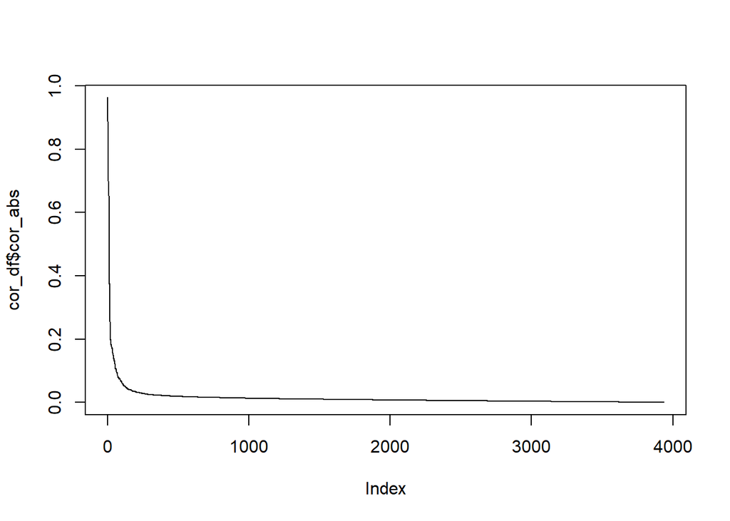

```r
tds <- data.frame(model.matrix( ~ .- 1, data=newdata))
cor_tds <- cor(tds, tds, method = "pearson")
cor_df<- data.frame(cor=cor_tds[1:3936,3937], varn = names(cor_tds[1:3936,3937]))
cor_df<- cor_df%>%mutate(cor_abs = abs(cor)) %>% arrange(desc(cor_abs))
plot(cor_df$cor_abs, type="l")
```

```r
list_varn <- cor_df %>% filter(cor_abs>0.3)
filter_df <- data.frame(tds) %>% select(G_SC,one_of(as.character(list_varn$varn)))
head(filter_df)
```

```
##   G_SC PERCENTILE X.2ND_DECILE. QUARTILE CR_PRO CC_PRO ENG_PRO QR_PRO BIO_S11
## 1  180         91             5        4     93     71      93     71      86
## 2  182         92             5        4     38     86      98     97     100
## 3  113          7             1        1      1     18      43     17      46
## 4  157         67             4        3     35     76      80     65      64
## 5  198         98             5        4     94     98     100     94      85
## 6  154         63             4        3     15     32      97     86      61
##   ENG_S11 CR_S11 MAT_S11 CC_S11 WC_PRO SEL_IHE FEP_PRO
## 1      82     81      71     61     79       2     181
## 2      88     75      83     66     78       4     201
## 3      42     49      52     38     22       1     113
## 4      73     55      56     51     48       2     137
## 5      92     65      80     76     71       2     189
## 6      82     60      71     57     36       2     170
```

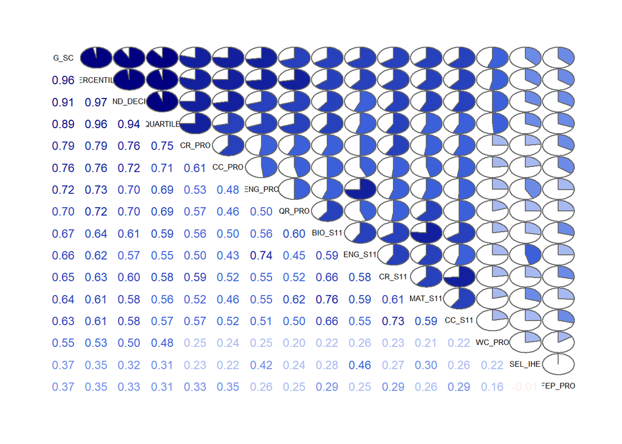

```r
library(corrgram)
corrgram(filter_df,lower.panel=panel.cor,upper.panel=panel.pie, cor.method = "pearson")
```

Check if data is suitable - look at the relevant Statistics Bartlett’s test

```r
raqMatrix<-cor(filter_df)
psych::cortest.bartlett(filter_df)
```

```
## R was not square, finding R from data
```

```
## $chisq
## [1] 227922
##
## $p.value
## [1] 0
##
## $df
## [1] 120
```

```r
psych::cortest.bartlett(raqMatrix, n=nrow(filter_df))
```

```
## $chisq
## [1] 227922
##
## $p.value
## [1] 0
##
## $df
## [1] 120
```

As the p value is less than <.05, this is significant with bartlett.

```r
View(filter_df)
```

```r
psych::KMO(filter_df)
```

```
## Kaiser-Meyer-Olkin factor adequacy
## Call: psych::KMO(r = filter_df)
## Overall MSA =  0.88
## MSA for each item =
##          G_SC    PERCENTILE X.2ND_DECILE.      QUARTILE        CR_PRO
##          0.88          0.83          0.92          0.93          0.86
##        CC_PRO       ENG_PRO        QR_PRO       BIO_S11       ENG_S11
##          0.80          0.84          0.83          0.95          0.94
##        CR_S11       MAT_S11        CC_S11        WC_PRO       SEL_IHE
##          0.95          0.94          0.95          0.53          0.94
##       FEP_PRO
##          0.95
```

```r
# checking for determinents

###Determinant
#Determinant (execute one of these):
det(raqMatrix)
```

```
## [1] 1.04661e-08
```

```r
det(cor(raqMatrix))
```

```
## [1] 1.008425e-29
```

performing dimensionality reduction

```r
#pcModel<-principal(dataframe/R-matrix, nfactors = number of factors, rotate = "method of rotation", scores = TRUE)

#On raw data using principal components analysis
#For PCA we know how many factors if is possible to find
#principal will work out our loadings of each variable onto each component, the proportion
#each component explained and the cumulative proportion of variance explained
pc1 <-  principal(filter_df, nfactors = 15, rotate = "none")
pc1 <-  principal(filter_df, nfactors = length(filter_df), rotate = "none")
pc1#output all details of the PCA
```

```
## Principal Components Analysis
## Call: principal(r = filter_df, nfactors = length(filter_df), rotate = "none")
## Standardized loadings (pattern matrix) based upon correlation matrix
##                PC1   PC2   PC3   PC4   PC5   PC6   PC7   PC8   PC9  PC10  PC11
## G_SC          0.96 -0.20  0.04  0.00  0.00 -0.01 -0.01 -0.03 -0.03  0.00  0.05
## PERCENTILE    0.96 -0.26  0.03 -0.08 -0.05  0.02 -0.03  0.01  0.01  0.00 -0.02
## X.2ND_DECILE. 0.92 -0.28  0.02 -0.11 -0.07  0.03 -0.03  0.02  0.03 -0.01 -0.06
## QUARTILE      0.91 -0.28  0.02 -0.13 -0.08  0.03 -0.04  0.03  0.05 -0.02 -0.08
## CR_PRO        0.80 -0.10 -0.18 -0.14 -0.16 -0.12  0.03  0.18 -0.46 -0.04  0.01
## CC_PRO        0.75 -0.19 -0.19 -0.05 -0.26 -0.30  0.15 -0.38  0.14  0.05  0.09
## ENG_PRO       0.78  0.13  0.24  0.13 -0.23  0.07 -0.38  0.03  0.13 -0.04 -0.23
## QR_PRO        0.75  0.05 -0.11 -0.30 -0.03  0.43  0.15  0.22  0.20  0.02  0.17
## BIO_S11       0.78  0.36 -0.12 -0.04  0.22  0.12  0.05 -0.20 -0.09 -0.06 -0.21
## ENG_S11       0.73  0.31  0.27  0.24 -0.07  0.00 -0.31 -0.05 -0.07  0.00  0.32
## CR_S11        0.76  0.30 -0.13  0.01  0.20 -0.29  0.00  0.20  0.07  0.38 -0.05
## MAT_S11       0.75  0.38 -0.06 -0.06  0.21  0.26  0.07 -0.26 -0.11  0.04  0.03
## CC_S11        0.74  0.30 -0.15  0.01  0.22 -0.33  0.07  0.15  0.15 -0.34  0.04
## WC_PRO        0.45 -0.57  0.33  0.20  0.56  0.01 -0.01 -0.02 -0.02  0.01  0.03
## SEL_IHE       0.41  0.20  0.71  0.18 -0.20 -0.02  0.45  0.06 -0.02  0.00 -0.05
## FEP_PRO       0.40 -0.12 -0.51  0.71 -0.11  0.18  0.13  0.07  0.01  0.00 -0.02
##                PC12  PC13  PC14  PC15  PC16 h2       u2 com
## G_SC           0.01  0.13  0.00 -0.16  0.03  1  2.2e-16 1.2
## PERCENTILE    -0.01 -0.04 -0.02 -0.04 -0.07  1 -5.6e-15 1.2
## X.2ND_DECILE. -0.01 -0.13 -0.18  0.02  0.03  1 -2.0e-15 1.4
## QUARTILE      -0.02 -0.21  0.15 -0.01  0.02  1 -2.2e-15 1.5
## CR_PRO        -0.02  0.08  0.02  0.05  0.00  1 -8.9e-16 2.2
## CC_PRO         0.02  0.08  0.02  0.06  0.00  1 -6.7e-16 2.9
## ENG_PRO       -0.09  0.14  0.02  0.04  0.00  1 -1.6e-15 2.5
## QR_PRO         0.07  0.09  0.01  0.04  0.00  1 -1.8e-15 2.8
## BIO_S11        0.31  0.00  0.00  0.00  0.00  1 -1.3e-15 2.5
## ENG_S11        0.12 -0.08  0.00  0.01  0.00  1 -6.7e-16 3.0
## CR_S11        -0.01 -0.01  0.00  0.00  0.00  1 -1.3e-15 2.7
## MAT_S11       -0.31 -0.03  0.00  0.00  0.00  1 -4.4e-16 2.8
## CC_S11        -0.07  0.00  0.00  0.00  0.00  1 -1.3e-15 2.9
## WC_PRO         0.01  0.07  0.02  0.06  0.00  1 -6.7e-16 3.9
## SEL_IHE        0.00 -0.01  0.00  0.00  0.00  1 -4.4e-16 3.0
## FEP_PRO       -0.01 -0.02  0.00  0.00  0.00  1 -6.7e-16 2.9
##
##                        PC1  PC2  PC3  PC4  PC5  PC6  PC7  PC8  PC9 PC10 PC11
## SS loadings           9.22 1.26 1.14 0.80 0.71 0.60 0.53 0.42 0.35 0.27 0.25
## Proportion Var        0.58 0.08 0.07 0.05 0.04 0.04 0.03 0.03 0.02 0.02 0.02
## Cumulative Var        0.58 0.65 0.73 0.78 0.82 0.86 0.89 0.92 0.94 0.96 0.97
## Proportion Explained  0.58 0.08 0.07 0.05 0.04 0.04 0.03 0.03 0.02 0.02 0.02
## Cumulative Proportion 0.58 0.65 0.73 0.78 0.82 0.86 0.89 0.92 0.94 0.96 0.97
##                       PC12 PC13 PC14 PC15 PC16
## SS loadings           0.22 0.13 0.05 0.04 0.01
## Proportion Var        0.01 0.01 0.00 0.00 0.00
## Cumulative Var        0.99 0.99 1.00 1.00 1.00
## Proportion Explained  0.01 0.01 0.00 0.00 0.00
## Cumulative Proportion 0.99 0.99 1.00 1.00 1.00
##
## Mean item complexity =  2.5
## Test of the hypothesis that 16 components are sufficient.
##
## The root mean square of the residuals (RMSR) is  0
##  with the empirical chi square  0  with prob <  NA
##
## Fit based upon off diagonal values = 1
```

significance of the filters

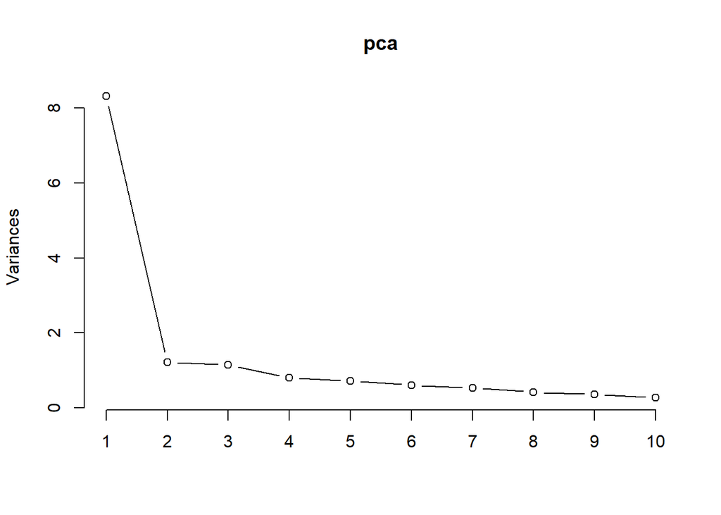

```r
xv <- filter_df %>% select(-G_SC)
pca = prcomp(xv, scale. = T, center = T)
plot(pca, type="l")
```

print the significance value

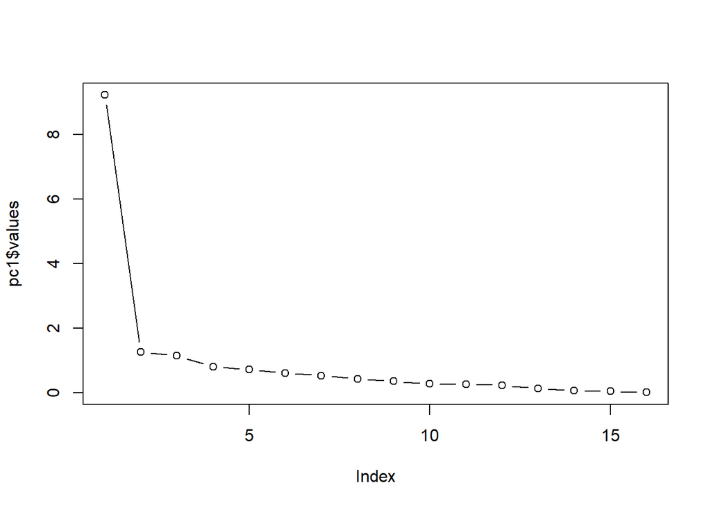

```r
#Create the scree plot
plot(pc1$values, type = "b")
```

```r
#Print the variance explained by each component
pc1$Vaccounted
```

```
##                             PC1        PC2        PC3        PC4       PC5
## SS loadings           9.2166093 1.25663481 1.14141338 0.80173336 0.7105744
## Proportion Var        0.5760381 0.07853968 0.07133834 0.05010834 0.0444109
## Cumulative Var        0.5760381 0.65457776 0.72591609 0.77602443 0.8204353
## Proportion Explained  0.5760381 0.07853968 0.07133834 0.05010834 0.0444109
## Cumulative Proportion 0.5760381 0.65457776 0.72591609 0.77602443 0.8204353
##                              PC6        PC7        PC8        PC9       PC10
## SS loadings           0.60186145 0.52637011 0.41591579 0.35199590 0.26555752
## Proportion Var        0.03761634 0.03289813 0.02599474 0.02199974 0.01659734
## Cumulative Var        0.85805167 0.89094980 0.91694454 0.93894429 0.95554163
## Proportion Explained  0.03761634 0.03289813 0.02599474 0.02199974 0.01659734
## Cumulative Proportion 0.85805167 0.89094980 0.91694454 0.93894429 0.95554163
##                             PC11       PC12        PC13        PC14        PC15
## SS loadings           0.25461516 0.22402468 0.132196986 0.054648984 0.038789179
## Proportion Var        0.01591345 0.01400154 0.008262312 0.003415562 0.002424324
## Cumulative Var        0.97145508 0.98545662 0.993718932 0.997134494 0.999558817
## Proportion Explained  0.01591345 0.01400154 0.008262312 0.003415562 0.002424324
## Cumulative Proportion 0.97145508 0.98545662 0.993718932 0.997134494 0.999558817
##                               PC16
## SS loadings           0.0070589224
## Proportion Var        0.0004411826
## Cumulative Var        1.0000000000
## Proportion Explained  0.0004411826
## Cumulative Proportion 1.0000000000
```

```r
#Print the Eigenvalues
View(pc1$values)
```

total evaluation

```r
pcf=princomp(filter_df)
factoextra::get_eigenvalue(pcf)
```

```
##          eigenvalue variance.percent cumulative.variance.percent
## Dim.1  3.761206e+03     52.536489452                    52.53649
## Dim.2  1.255289e+03     17.533865030                    70.07035
## Dim.3  7.774480e+02     10.859386866                    80.92974
## Dim.4  4.258377e+02      5.948097059                    86.87784
## Dim.5  3.274616e+02      4.573980816                    91.45182
## Dim.6  2.565098e+02      3.582926881                    95.03475
## Dim.7  1.363391e+02      1.904383769                    96.93913
## Dim.8  6.299299e+01      0.879885533                    97.81902
## Dim.9  5.372765e+01      0.750467286                    98.56948
## Dim.10 2.974492e+01      0.415476714                    98.98496
## Dim.11 2.698792e+01      0.376966996                    99.36193
## Dim.12 2.665297e+01      0.372288384                    99.73421
## Dim.13 1.827335e+01      0.255242034                    99.98946
## Dim.14 6.327543e-01      0.008838307                    99.99830
## Dim.15 6.761846e-02      0.000944494                    99.99924
## Dim.16 5.443732e-02      0.000760380                   100.00000
```

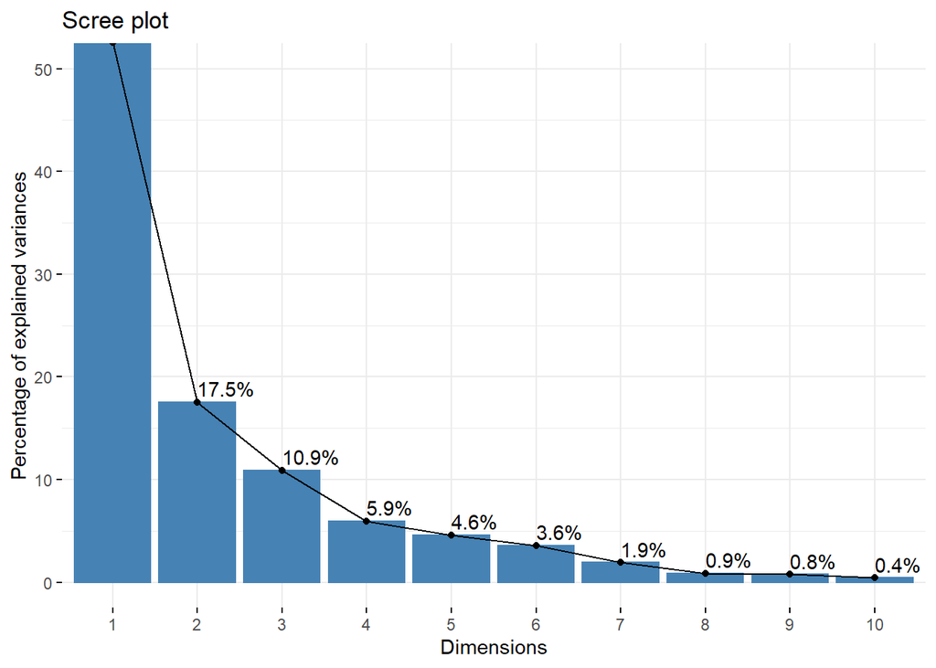

```r
factoextra::fviz_eig(pcf, addlabels = TRUE, ylim = c(0, 50))#Visualize the Eigenvalues
```

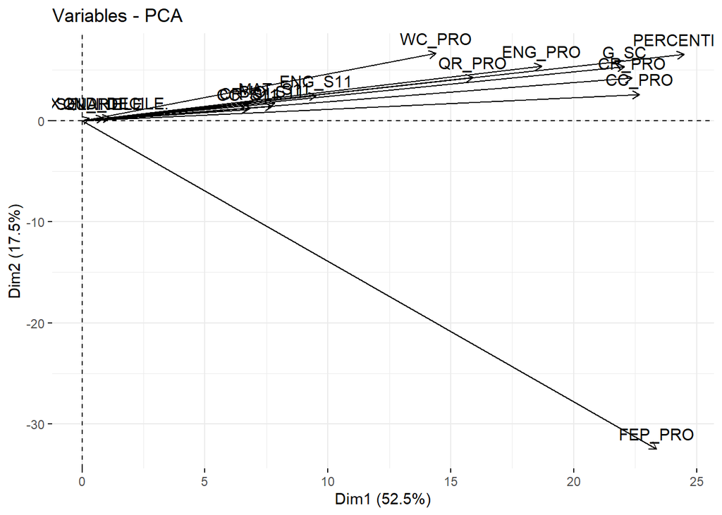

```r
factoextra::fviz_pca_var(pcf, col.var = "black")
```

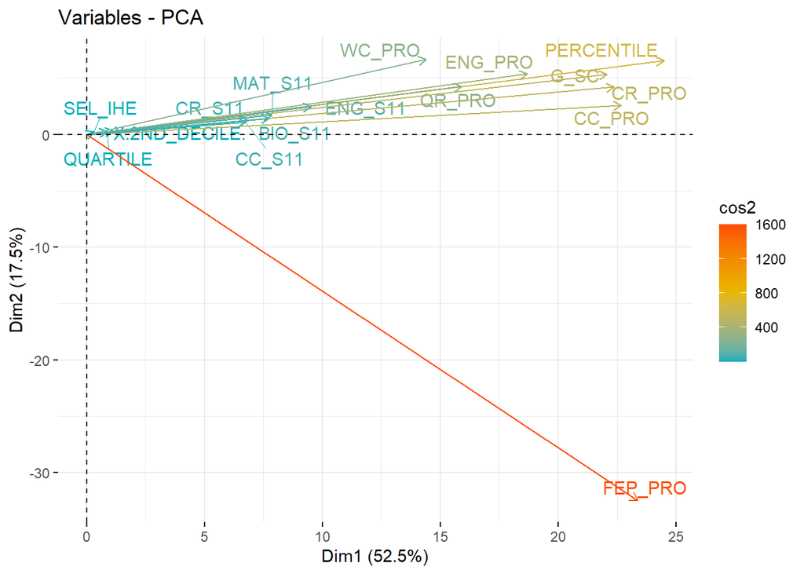

```r
factoextra::fviz_pca_var(pcf, col.var = "cos2",
             gradient.cols = c("#00AFBB", "#E7B800", "#FC4E07"),
             repel = TRUE # Avoid text overlapping
             )
```

```r
#Print the loadings above the level of 0.3
psych::print.psych(pc1, cut = 0.3, sort = TRUE)
```

```
## Principal Components Analysis
## Call: principal(r = filter_df, nfactors = length(filter_df), rotate = "none")
## Standardized loadings (pattern matrix) based upon correlation matrix
##               item  PC1   PC2   PC3   PC4   PC5   PC6   PC7   PC8   PC9  PC10
## PERCENTILE       2 0.96
## G_SC             1 0.96
## X.2ND_DECILE.    3 0.92
## QUARTILE         4 0.91
## CR_PRO           5 0.80                                           -0.46
## ENG_PRO          7 0.78                               -0.38
## BIO_S11          9 0.78  0.36
## CR_S11          11 0.76  0.30                                            0.38
## QR_PRO           8 0.75             -0.30        0.43
## MAT_S11         12 0.75  0.38
## CC_PRO           6 0.75                         -0.30       -0.38
## CC_S11          13 0.74  0.30                   -0.33                   -0.34
## ENG_S11         10 0.73  0.31                         -0.31
## WC_PRO          14 0.45 -0.57  0.33        0.56
## SEL_IHE         15 0.41        0.71                    0.45
## FEP_PRO         16 0.40       -0.51  0.71
##                PC11  PC12 PC13 PC14 PC15 PC16 h2       u2 com
## PERCENTILE                                     1 -5.6e-15 1.2
## G_SC                                           1  2.2e-16 1.2
## X.2ND_DECILE.                                  1 -2.0e-15 1.4
## QUARTILE                                       1 -2.2e-15 1.5
## CR_PRO                                         1 -8.9e-16 2.2
## ENG_PRO                                        1 -1.6e-15 2.5
## BIO_S11              0.31                      1 -1.3e-15 2.5
## CR_S11                                         1 -1.3e-15 2.7
## QR_PRO                                         1 -1.8e-15 2.8
## MAT_S11             -0.31                      1 -4.4e-16 2.8
## CC_PRO                                         1 -6.7e-16 2.9
## CC_S11                                         1 -1.3e-15 2.9
## ENG_S11        0.32                            1 -6.7e-16 3.0
## WC_PRO                                         1 -6.7e-16 3.9
## SEL_IHE                                        1 -4.4e-16 3.0
## FEP_PRO                                        1 -6.7e-16 2.9
##
##                        PC1  PC2  PC3  PC4  PC5  PC6  PC7  PC8  PC9 PC10 PC11
## SS loadings           9.22 1.26 1.14 0.80 0.71 0.60 0.53 0.42 0.35 0.27 0.25
## Proportion Var        0.58 0.08 0.07 0.05 0.04 0.04 0.03 0.03 0.02 0.02 0.02
## Cumulative Var        0.58 0.65 0.73 0.78 0.82 0.86 0.89 0.92 0.94 0.96 0.97
## Proportion Explained  0.58 0.08 0.07 0.05 0.04 0.04 0.03 0.03 0.02 0.02 0.02
## Cumulative Proportion 0.58 0.65 0.73 0.78 0.82 0.86 0.89 0.92 0.94 0.96 0.97
##                       PC12 PC13 PC14 PC15 PC16
## SS loadings           0.22 0.13 0.05 0.04 0.01
## Proportion Var        0.01 0.01 0.00 0.00 0.00
## Cumulative Var        0.99 0.99 1.00 1.00 1.00
## Proportion Explained  0.01 0.01 0.00 0.00 0.00
## Cumulative Proportion 0.99 0.99 1.00 1.00 1.00
##
## Mean item complexity =  2.5
## Test of the hypothesis that 16 components are sufficient.
##
## The root mean square of the residuals (RMSR) is  0
##  with the empirical chi square  0  with prob <  NA
##
## Fit based upon off diagonal values = 1
```

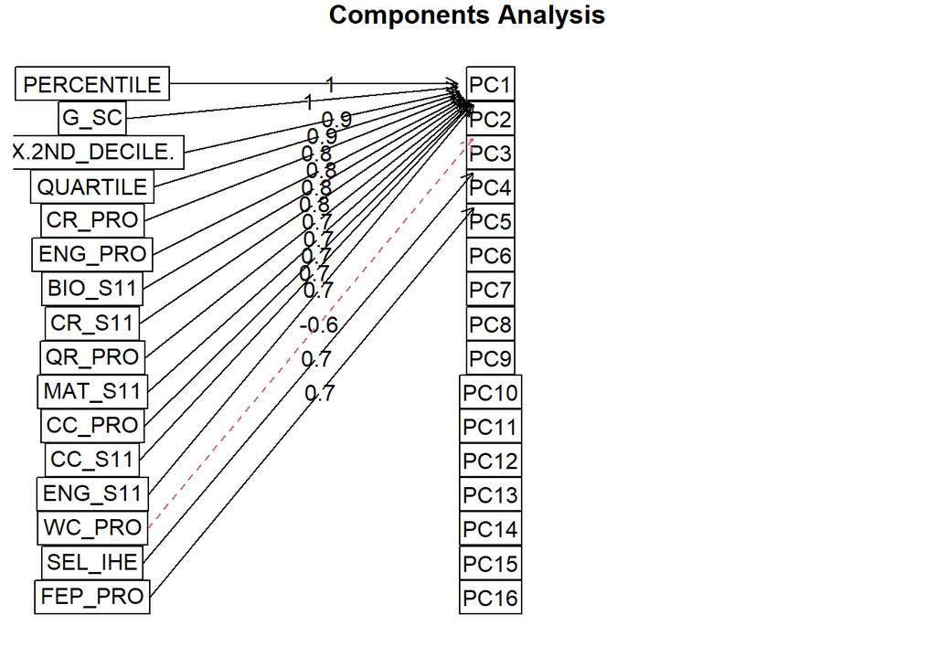

```r
#create a diagram showing the components and how the manifest variables load
fa.diagram(pc1)
```

```r
#Show the loadings of variables on to components
fa.sort(pc1$loading)
```

```
##
## Loadings:
##               PC1    PC2    PC3    PC4    PC5    PC6    PC7    PC8    PC9
## PERCENTILE     0.956 -0.255
## G_SC           0.956 -0.196
## X.2ND_DECILE.  0.921 -0.277        -0.114
## QUARTILE       0.905 -0.280        -0.128
## CR_PRO         0.801        -0.176 -0.137 -0.159 -0.120         0.184 -0.463
## ENG_PRO        0.777  0.128  0.239  0.131 -0.233        -0.382         0.127
## BIO_S11        0.777  0.356 -0.117         0.220  0.123        -0.199
## CR_S11         0.761  0.305 -0.125         0.200 -0.288         0.202
## QR_PRO         0.748        -0.115 -0.302         0.425  0.147  0.217  0.202
## MAT_S11        0.747  0.377                0.206  0.260        -0.259 -0.111
## CC_PRO         0.746 -0.189 -0.194        -0.256 -0.300  0.152 -0.385  0.143
## CC_S11         0.741  0.304 -0.154         0.224 -0.333         0.155  0.154
## ENG_S11        0.735  0.310  0.266  0.244               -0.313
## WC_PRO         0.446 -0.574  0.333  0.202  0.557
## SEL_IHE        0.412  0.201  0.710  0.183 -0.205         0.450
## FEP_PRO        0.402 -0.116 -0.508  0.705 -0.108  0.182  0.135
##               PC10   PC11   PC12   PC13   PC14   PC15   PC16
## PERCENTILE
## G_SC                                0.128        -0.158
## X.2ND_DECILE.                      -0.130 -0.176
## QUARTILE                           -0.211  0.147
## CR_PRO
## ENG_PRO              -0.227         0.142
## BIO_S11              -0.208  0.307
## CR_S11         0.375
## QR_PRO                0.166
## MAT_S11                     -0.310
## CC_PRO
## CC_S11        -0.337
## ENG_S11               0.319  0.118
## WC_PRO
## SEL_IHE
## FEP_PRO
##
##                  PC1   PC2   PC3   PC4   PC5   PC6   PC7   PC8   PC9  PC10
## SS loadings    9.217 1.257 1.141 0.802 0.711 0.602 0.526 0.416 0.352 0.266
## Proportion Var 0.576 0.079 0.071 0.050 0.044 0.038 0.033 0.026 0.022 0.017
## Cumulative Var 0.576 0.655 0.726 0.776 0.820 0.858 0.891 0.917 0.939 0.956
##                 PC11  PC12  PC13  PC14  PC15  PC16
## SS loadings    0.255 0.224 0.132 0.055 0.039 0.007
## Proportion Var 0.016 0.014 0.008 0.003 0.002 0.000
## Cumulative Var 0.971 0.985 0.994 0.997 1.000 1.000
```

```r
#Output the communalities of variables across components (will be one for PCA since all the variance is used)
pc1$communality
```

```
##          G_SC    PERCENTILE X.2ND_DECILE.      QUARTILE        CR_PRO
##             1             1             1             1             1
##        CC_PRO       ENG_PRO        QR_PRO       BIO_S11       ENG_S11
##             1             1             1             1             1
##        CR_S11       MAT_S11        CC_S11        WC_PRO       SEL_IHE
##             1             1             1             1             1
##       FEP_PRO
##             1
```

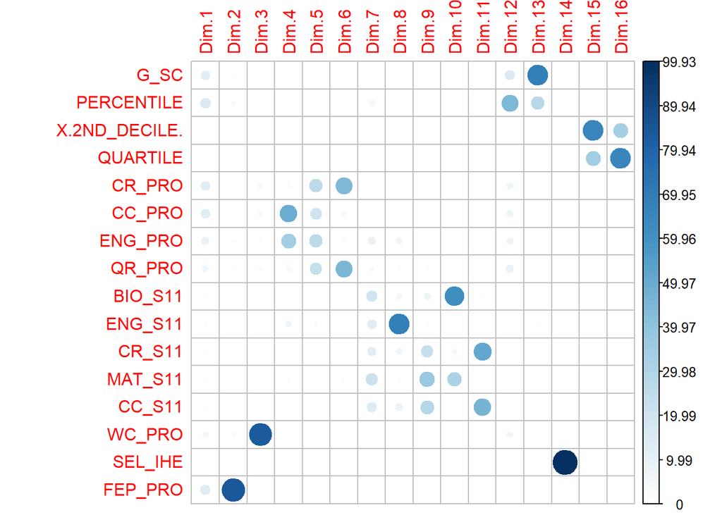

```r
#Visualize contribution of variables to each component
var <- factoextra::get_pca_var(pcf)
corrplot::corrplot(var$contrib, is.corr=FALSE)
```

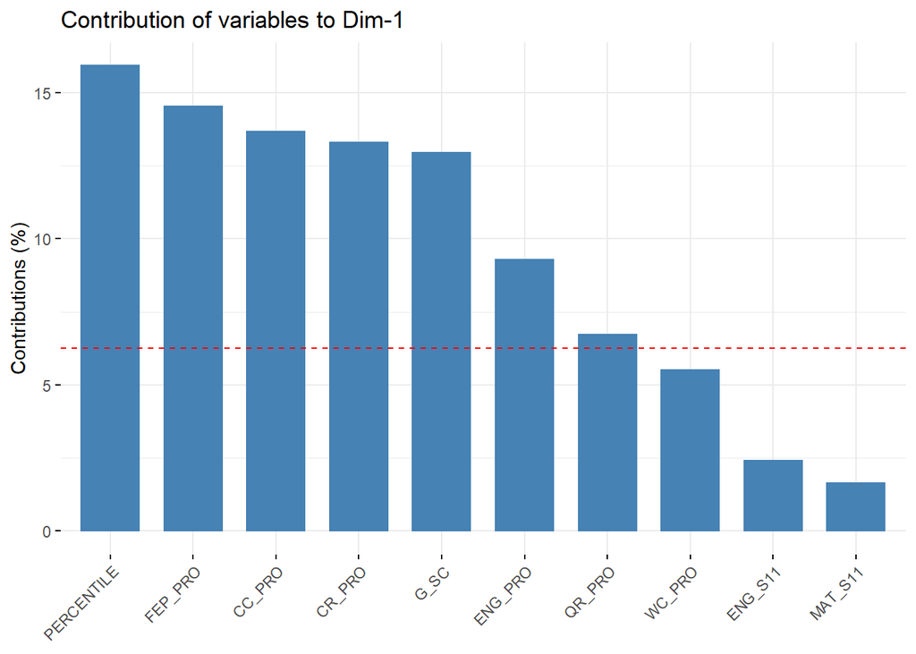

```r
# Contributions of variables to PC1
factoextra::fviz_contrib(pcf, choice = "var", axes = 1, top = 10)
```

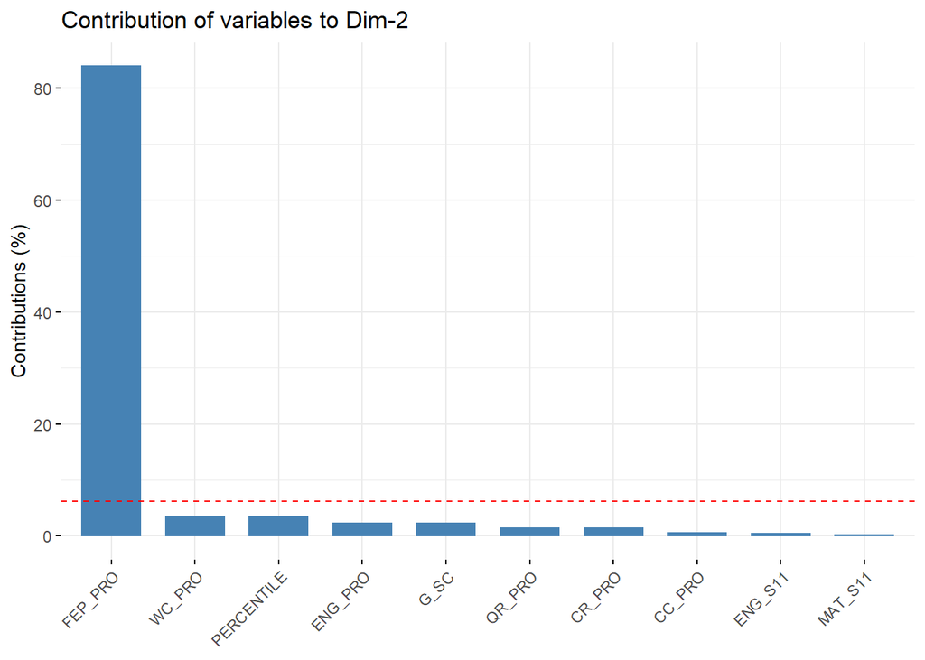

```r
# Contributions of variables to PC2
factoextra::fviz_contrib(pcf, choice = "var", axes = 2, top = 10)
```

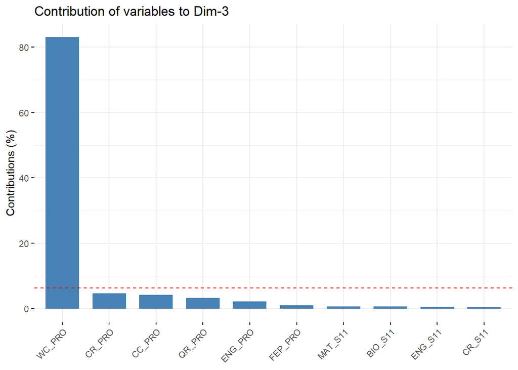

```r
# Contributions of variables to PC3
factoextra::fviz_contrib(pcf, choice = "var", axes = 3, top = 10)
```

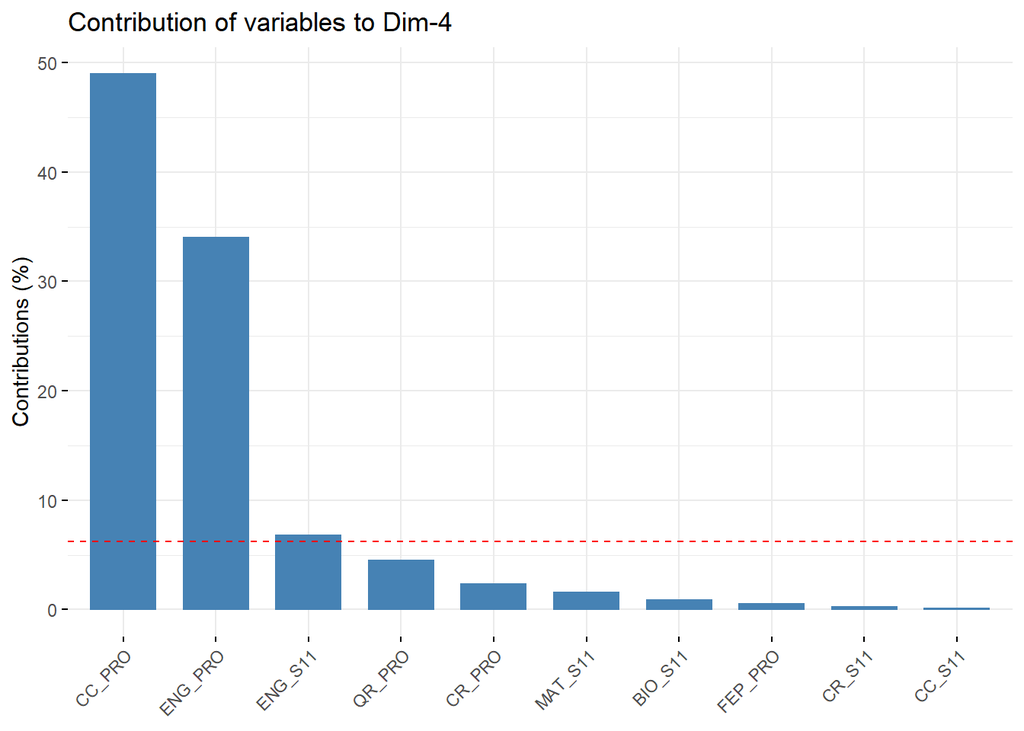

```r
# Contributions of variables to PC4
factoextra::fviz_contrib(pcf, choice = "var", axes = 4, top = 10)
```

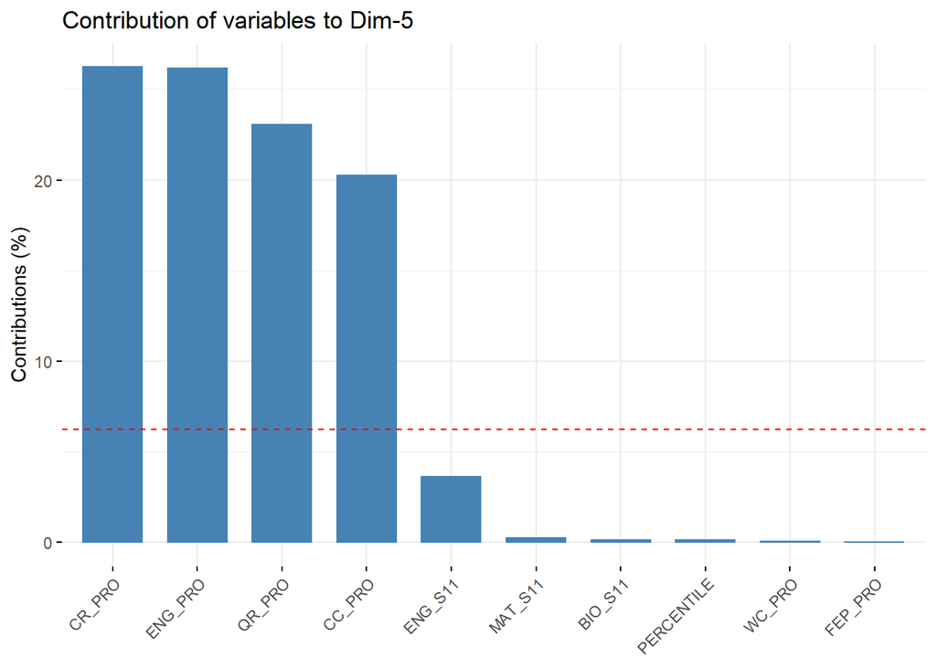

```r
# Contributions of variables to PC5
factoextra::fviz_contrib(pcf, choice = "var", axes = 5, top = 10)
```

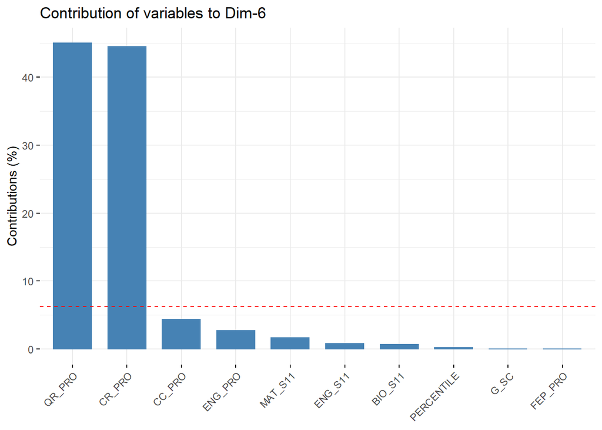

```r
# Contributions of variables to PC6
factoextra::fviz_contrib(pcf, choice = "var", axes = 6, top = 10)
```

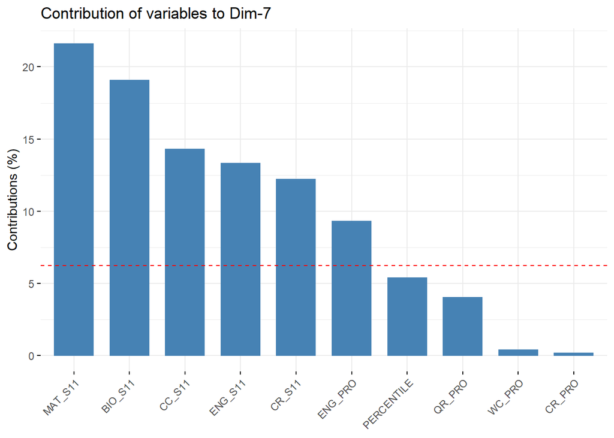

```r
# Contributions of variables to PC7
factoextra::fviz_contrib(pcf, choice = "var", axes = 7, top = 10)
```

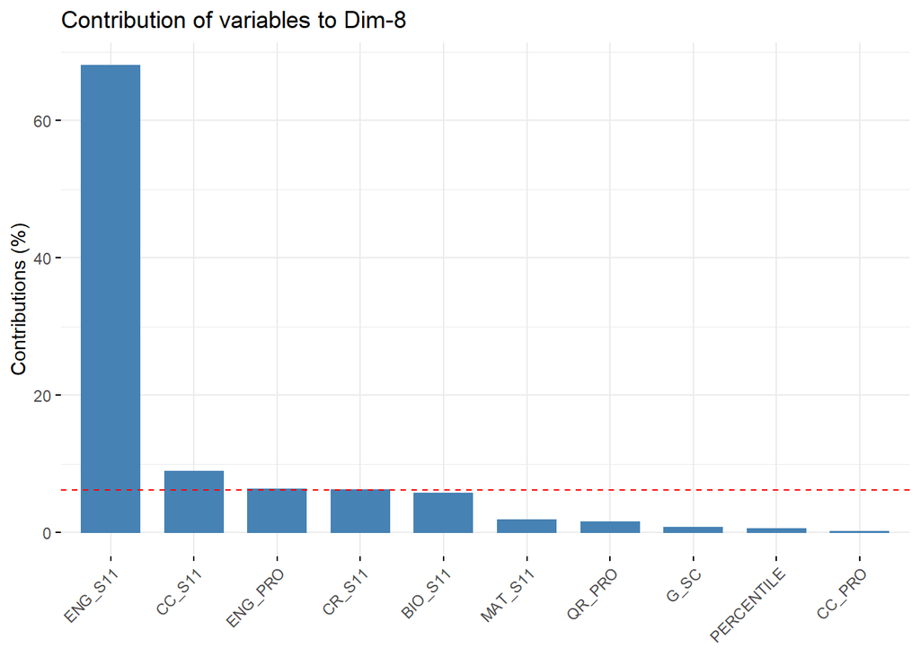

```r
# Contributions of variables to PC8
factoextra::fviz_contrib(pcf, choice = "var", axes = 8, top = 10)
```

do factor rotation

```r
#Apply rotation to try to refine the component structure
pc2 <-  principal(filter_df, nfactors = 15, rotate = "varimax")#Extracting 4 factors
#output the components
psych::print.psych(pc2, cut = 0.3, sort = TRUE)
```

```
## Principal Components Analysis
## Call: principal(r = filter_df, nfactors = 15, rotate = "varimax")
## Standardized loadings (pattern matrix) based upon correlation matrix
##               item  RC1  RC5   RC3  RC2   RC4 RC15 RC11 RC10  RC6  RC8 RC12
## QUARTILE         4 0.85
## X.2ND_DECILE.    3 0.82
## PERCENTILE       2 0.76
## G_SC             1 0.62 0.32
## WC_PRO          14      0.95
## SEL_IHE         15            0.96
## MAT_S11         12                 0.81
## FEP_PRO         16                       0.97
## CC_S11          13                            0.82
## ENG_S11         10                                 0.81
## CR_S11          11                            0.31      0.79
## QR_PRO           8 0.46                                      0.80
## CC_PRO           6 0.51                                           0.78
## BIO_S11          9                 0.35                                0.74
## ENG_PRO          7 0.45                            0.34
## CR_PRO           5 0.57
##                RC7  RC9 RC14 RC13   h2      u2 com
## QUARTILE                          1.00 3.1e-04 1.9
## X.2ND_DECILE.                     1.00 6.5e-04 2.2
## PERCENTILE                        0.99 5.4e-03 2.8
## G_SC                              1.00 6.3e-04 5.4
## WC_PRO                            1.00 5.1e-06 1.2
## SEL_IHE                           1.00 6.9e-08 1.2
## MAT_S11                           1.00 8.1e-08 2.2
## FEP_PRO                           1.00 1.2e-07 1.1
## CC_S11                            1.00 1.9e-08 2.1
## ENG_S11                           1.00 3.2e-07 2.2
## CR_S11                            1.00 2.9e-09 2.4
## QR_PRO                            1.00 5.7e-06 2.2
## CC_PRO                            1.00 5.2e-06 2.2
## BIO_S11                           1.00 3.0e-08 3.0
## ENG_PRO       0.73                1.00 5.5e-06 2.9
## CR_PRO             0.71           1.00 5.4e-06 2.8
##
##                        RC1  RC5  RC3  RC2  RC4 RC15 RC11 RC10  RC6  RC8 RC12
## SS loadings           3.84 1.21 1.14 1.12 1.11 1.10 1.10 1.00 0.98 0.93 0.85
## Proportion Var        0.24 0.08 0.07 0.07 0.07 0.07 0.07 0.06 0.06 0.06 0.05
## Cumulative Var        0.24 0.32 0.39 0.46 0.53 0.59 0.66 0.73 0.79 0.85 0.90
## Proportion Explained  0.24 0.08 0.07 0.07 0.07 0.07 0.07 0.06 0.06 0.06 0.05
## Cumulative Proportion 0.24 0.32 0.39 0.46 0.53 0.60 0.66 0.73 0.79 0.85 0.90
##                        RC7  RC9 RC14 RC13
## SS loadings           0.79 0.71 0.06 0.06
## Proportion Var        0.05 0.04 0.00 0.00
## Cumulative Var        0.95 0.99 1.00 1.00
## Proportion Explained  0.05 0.04 0.00 0.00
## Cumulative Proportion 0.95 0.99 1.00 1.00
##
## Mean item complexity =  2.4
## Test of the hypothesis that 15 components are sufficient.
##
## The root mean square of the residuals (RMSR) is  0
##  with the empirical chi square  0.24  with prob <  NA
##
## Fit based upon off diagonal values = 1
```

```r
#output the communalities
pc2$communality
```

```
##          G_SC    PERCENTILE X.2ND_DECILE.      QUARTILE        CR_PRO
##     0.9993692     0.9945584     0.9993543     0.9996868     0.9999946
##        CC_PRO       ENG_PRO        QR_PRO       BIO_S11       ENG_S11
##     0.9999948     0.9999945     0.9999943     1.0000000     0.9999997
##        CR_S11       MAT_S11        CC_S11        WC_PRO       SEL_IHE
##     1.0000000     0.9999999     1.0000000     0.9999949     0.9999999
##       FEP_PRO
##     0.9999999
```

```r
#NOTE: you can do all the other things done for the model created in pc1
```